```python
import numpy as np
import sympy
import matplotlib.pyplot as plt
from IPython.display import display, Math
```

# Números Complexos

A exigência para números complexos:

Imagine que estamos buscando pelas raízes da função: $f(z)=Az^2 + Bz +C$

- Se usarmos A=1, B=-2 e C=2, temos $f(z)=0 \rightarrow z^2 - 2z +2=0$.
- Resulta em $z=1\pm\frac{\sqrt{-4}}{2}$

De fato, para tais valores a função $f(z)$ não apresenta soluções reais. Veja na figura abaixo três exemplos. Os números complexos possuem aplicações em tais casos. Por exemplo, o caso mais simples em que: $$z^2+1=0,$$ onde é necessário usar um número imaginário $i$ tal que $i^2=-1$, para ser raiz desta equação.

[figure not shown]

```python
z = sympy.Symbol('z');f1 = z**2 - 2*z +2;f2 = z**2 - 4*z +5;f3 = z**2 - 3*z +3
p1=sympy.plotting.plot(f1, (z, -4, 6),line_color='blue',
                       title=r'$f(z)=az^2 + bz +c$',label=r'$f(z)=z^2 - 2z +2$',
                       xlabel=r'$f(z)$', ylabel=r'$z$',xlim=(0,3),ylim=(-1.2,3),show=False,legend=True,
                      legend_loc='lower right')#axis_center=(0,0),)
p1.append(sympy.plotting.plot(f2, (z, -4, 8),line_color='red',
                       title=r'$f(z)=az^2 + bz +c$',label=r'$f(z)=z^2 - 4z +5$',
                       xlabel=r'$f(z)$', ylabel=r'$z$',xlim=(-1,3),ylim=(0,3),show=False,legend=True,
                      legend_loc='lower right')[0])
p1.append(sympy.plotting.plot(f3, (z, -4, 8),line_color='orange',
                       title=r'$f(z)=az^2 + bz +c$',label=r'$f(z)=z^2 - 2z +9$',
                       xlabel=r'$f(z)$', ylabel=r'$z$',xlim=(-1,3),ylim=(0,3),show=False,legend=True,
                      legend_loc='lower right')[0])
p1.legend_loc = 'upper left'
p1.show()
```

A função quadrática $f(z)=f(z)=z^2 - 2z +2$ tem duas soluções possíveis: $z=1\pm\frac{\sqrt{-4}}{2}$.

Denotaremos a parte real da solução por:

- $\mathfrak{Re}(z)=1$

A parte imaginária será denotada por:

- $\mathfrak{Im}(z)=\pm1 \textrm{ que vem de }\rightarrow \pm\frac{\sqrt{-4}}{2}=\pm\frac{\sqrt{2^2(-1)}}{2}=\pm1 \sqrt{-1}$

### Definimos a unidade imaginária

- $i\equiv\sqrt{-1}$

Não confunda com a unidade z=(1,0)

- $i^2=-1$
- Podemos usar a seguinte notação para um número complexo $z=(a,b)$ ou $z=a+ib$

Obtenha uma relação entre os valores $\mathfrak{Re}(z)$ e $\mathfrak{Im}(z)$ com o gráfico de $f(z)$ no plano cartesiano real.

Calcule os $x_v=\frac{-B}{2A}$ e $y_v=\frac{-\Delta}{4A}$

Então, observe que o mínimo no eixo horizontal é relacionado com a parte real das raízes de $f(z)$. E o mínimo vertical é proporcional ao quadrado da parte imaginária.

$$x_v=\mathfrak{Re}(z)\textrm{ e }y_v=A (\mathfrak{Im}(z))^2$$

# Definição de um número complexo.

Dados dois números reais a e b, um número complexo pode ser definindo como um par ordenado:

- $z\equiv(a,b)$

Assim, um número complexo é qualquer número da forma $z=(a,b)$, ou $z=a+ib$, onde $a$ e $b$ são números reais e em geral, $(a,b) \ne (b,a) \rightarrow a+ib \ne b+ia$

No caso acima para as raízes de $f_1(z)$ temos:

- $z_1=(1,+1)$ e $z_2=(1,-1)$
- Por tradição, o símbolo $\sqrt{-1}$ é representado por $i$, ou $j$.
- Ou seja, lembramos que a unidade imaginária é definida como $i=\sqrt{-1}$.
- E que $i^2=-1$

As raízes de $f_1(z)$ podem ser escritas como um número complexo construído a partir da unidade complexa:

- $z_i=1\pm 1 i=1\pm i \rightarrow z_i=(1,\pm 1)$

A notação para números complexos z=(a,b) é comumente utilizada em programação. Já a notação $z=a+ib$ é útil para realizar operações. FORTran é um exemplo, veja como ficaria $z=1-i$ definido em FORTRAN:

```
complex :: z2 = (1.0, -1.0)
```

No interpretador Python temos algo similar:

```
z2 = complex(1.0, -1.0) #(Parte Real, Parte Imag.)
print(z)
```

Ou, podemos usar a notação $z=a+ib=1+1i$ (observe que Python usa j ):

```
z1 = 1.0+1.0j # Observe que em Python não usamos i, mas sim letra j para representar a parte imaginária
print(z)
```

Assim temos uma ferramenta simples para nos ajudar a fazer operações com números complexos. Veja como seriam algumas operações com $z_1$ e $z_2$ em python.

```python
z2 = complex(1.0, -1.0) # Ambas as notações são equivalentes!
print("z2=",z2)
z1 = 1.0+1.0j
print("z1=",z1)
print("A soma é",z1+z2, "puramente real, neste caso.")
print("A subtração z1-z2 é",z1-z2)
print("e z2-z1",z2-z1)
print("O produto é",z1*z2)
print("a divisão z1/z2 é",z1/z2,"e para z2/z1 temos",z2/z1)
```

```
z2= (1-1j)
z1= (1+1j)
A soma é (2+0j) puramente real, neste caso.
A subtração z1-z2 é 2j
e z2-z1 -2j
O produto é (2+0j)
a divisão z1/z2 é 1j e para z2/z1 temos -1j
```

## Definição de uma variável complexa.

Dada duas variáveis reais *x* e *y*, de forma similar, temos uma variável complexa:

- $z=(x,y) \rightarrow z=x+iy$

## Definição de uma função complexa.

E igualmente podemos definir uma função complexa:

- $z=(f(x,y),g(x,y)) \rightarrow z=f+ig$

onde $f(x,y)$ e $g(x,y), ~x$ e $y$ são reais.

# Igualdade

Os números complexos $z_1$ e $z_2$ são iguais, $z_1=z_2$ se:

- $\mathfrak{Re}(z_1)=\mathfrak{Re}(z_2)$ e $\mathfrak{Im}(z_1)=\mathfrak{Im}(z_2)$

# Conjunto de números complexos

Vamos denotar a totalidade dos números complexos com o símbolo $\mathbb{C}$: $$\mathbb{C}=\{a+ib;a,b \in \mathbb{R}\}$$

O conjunto de números reais $\mathbb{R}$ é um subconjunto de $\mathbb{C}$, sendo escrito como $(a,0)$ ou $a+i0$

# Representação em forma de coordenadas

Um número complexo $z$ pode ser representado por um par ordenado $(a,b)$ de números reais $a$ e $b$, podemos representar um número complexo como um ponto em um gráfico.

**Definindo:**

- A abscissa vai representar a parte real, $\mathfrak{Re}z$;
- A ordenada vai representar a parte imaginária, $\mathfrak{Im}z$;
- Os pontos são igualmente espaçados;
- Números puramente imaginários estão sobre o eixo $\mathfrak{Im}$, (0,b).
- Números puramente reais estão sobre o eixo $\mathfrak{Re}$, (a,0).

Tal gráfico é chamado de plano de Argand, ou diagrama de Argand ou simplesmente plano complexo ou de Argand-Gauss.

Na maioria dos casos vamos utilizar o termo plano complexo.

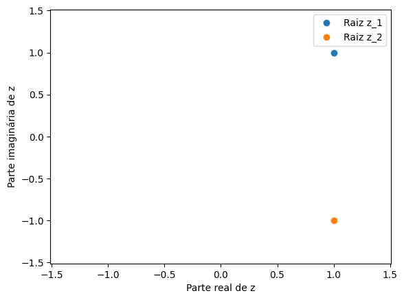

```python
plt.plot(z1.real,z1.imag,"o",label="Raiz z_1")
plt.plot(z1.real,z2.imag,"o",label="Raiz z_2")
plt.xlim(-1.51,1.51)
plt.ylim(-1.51,1.51)
plt.xlabel("Parte real de z")
plt.ylabel("Parte imaginária de z")
plt.legend()
plt.show()
```

O gráfico acima é chamado de plano de Argand ou plano complexo. Cada ponto representa um das raízes discutidas anteriormente: $$z=1\pm1i$$ Cada ponto pode ser também visualizado como um vetor partindo da origem.

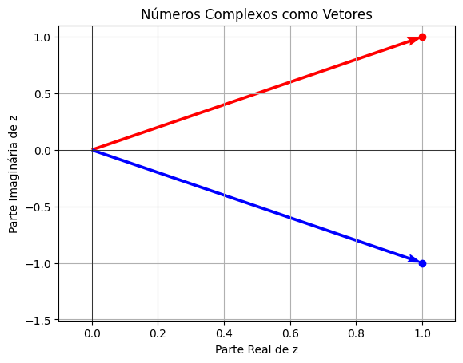

```python
plt.quiver( [0,0],[0,0],[z1.real,z2.real], [z1.imag,z2.imag] , angles='xy', scale_units='xy', scale=1, color=['r','b'])
plt.plot(z1.real,z1.imag,"o",label="Raíz z_1",color="red")
plt.plot(z1.real,z2.imag,"o",label="Raíz z_2",color="blue")
plt.xlim(-0.1, 1.1)
plt.ylim(-1.51, 1.1)
plt.xlabel('Parte Real de z')
plt.ylabel('Parte Imaginária de z')
plt.title('Números Complexos como Vetores')
plt.grid(True)
plt.axhline(0, color='black', linewidth=0.5)
plt.axvline(0, color='black', linewidth=0.5)
plt.show()
```

Relembrando o plano cartesiando no conjunto de números reais. Se tenho dois pontos $P_1=(5,4)$ e $P_2=(7,2)$, $P_2+P_1=(12,6)$

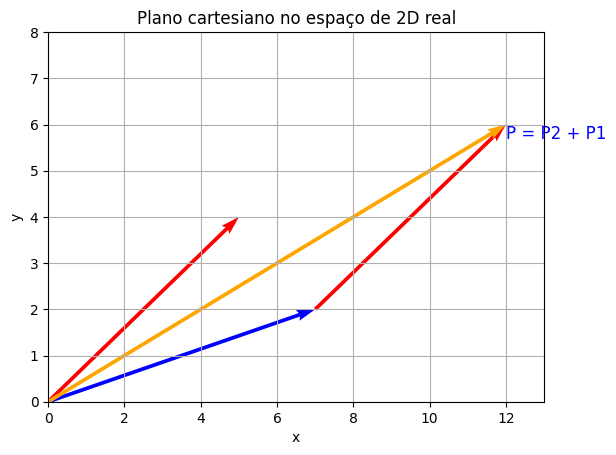

```python
plt.quiver( [0,0],[0,0],[5,7], [4,2] , angles='xy', scale_units='xy', scale=1, color=['r','b'])
#(origem x, origem y, x do vetores, y dos vetores)
plt.quiver( [7],[2],[5], [4] , angles='xy', scale_units='xy', scale=1, color=['r'])
plt.quiver( [0],[0],[12], [6] , angles='xy', scale_units='xy', scale=1, color=['orange'])
plt.text(12, 6, 'P = P2 + P1', color='b', fontsize=12, ha='left', va='top')
plt.xlim(0, 13)
plt.ylim(0, 8)
plt.xlabel('x')
plt.ylabel('y')
plt.title('Plano cartesiano no espaço de 2D real')
plt.grid(True)
plt.axhline(0, color='black', linewidth=0.5)
plt.axvline(0, color='black', linewidth=0.5)
plt.show()
```

# Soma de números complexos

No plano complexo temos algo similar, podemos fazer uma representação gráfica da soma.

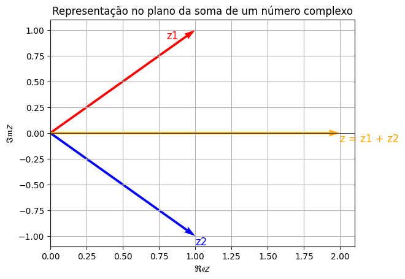

```python
plt.quiver( [0,0],[0,0],[z1.real,z2.real], [z1.imag,z2.imag] , angles='xy', scale_units='xy', scale=1, color=['r','b'])
plt.text((z1).real-0.2, (z1).imag, 'z1', color='r', fontsize=12, ha='left', va='top')
plt.text((z2).real, (z2).imag, 'z2', color='b', fontsize=12, ha='left', va='top')
#plt.quiver( [z1.real],[z1.imag],[z2.real], [z2.imag] , angles='xy', scale_units='xy', scale=1, color=['b'])
plt.quiver( [0],[0],[(z1+z2).real], [(z1+z2).imag] , angles='xy', scale_units='xy', scale=1, color=['orange'])
plt.text((z1+z2).real, (z1+z2).imag, 'z = z1 + z2', color='orange', fontsize=12, ha='left', va='top')
plt.xlim(0, 2.1)
plt.ylim(-1.1, 1.1)
plt.xlabel(r'$\mathfrak{Re}z$')
plt.ylabel(r'$\mathfrak{Im}z$')
plt.title('Representação no plano da soma de um número complexo')
plt.grid(True)
plt.axhline(0, color='black', linewidth=0.5)
plt.axvline(0, color='black', linewidth=0.5)
plt.show()
```

O módulo, ou valor absoluto, de $z$, é de forma similar calculado como: $$|z|=\sqrt{(\mathfrak{Re}z)^2+(\mathfrak{Im}z)^2}, \textrm{ onde: } z=\mathfrak{Re}z+i\mathfrak{Im}z=a+ib$$

```
# Em python calculamos o módulo como:
abs(z)
```

**Em resumo, para somar dois números complexos basta somar as correspondentes partes reais e imaginárias.:**

Por exemplo, faça a soma dos seguintes números complexos:

- $z_1=1+2i, ~z_2=3-4i, ~z_3=-2+i$
- $z_1+z_2+z_3= \left(\mathfrak{Re}z_1+\mathfrak{Re}z_2+\mathfrak{Re}z_3\right)+i \left(\mathfrak{Im}z_1+\mathfrak{Im}z_2+\mathfrak{Im}z_3\right)$
- $z_1+z_2+z_3= 2-i$

Podemos verificar usando o seguinte código em Python:

```
z_1=1+2j; z_2=3-4j; z_3=-2+1j #observe que ao usar a notação a+ib, o i é escrito como 1j e não apenas como j!!
print(z_1+z_2+z_3)
```

O qual imprime o resultado (2-1j), lembrando que 1j é a unidade imaginária $i$, $(1j)(1j)=-1$. Veja abaixo:

```python
z_1=1+2j; z_2=3-4j; z_3=-2+1j #observe que ao usar a notação a+ib, o i é escrito como 1j e não apenas como j!!
print(r"a soma z_1+z_2+z_3 =",z_1+z_2+z_3,"com a parte real dada por :",(z_1+z_2+z_3).real," e imaginária : ", (z_1+z_2+z_3).imag)
```

```
a soma z_1+z_2+z_3 = (2-1j) com a parte real dada por : 2.0  e imaginária :  -1.0
```

# Produto de números complexos

A multiplicação entre $z_1$ e $z_2$ é definida como: $$z_1z_2=(a_1,b_1)(a_2,b_2)=(a_1a_2-b_1b_2,a_1b_2+a_2b_1)$$

O que na notação $a+ib$ é:

$$z_1z_2=(a_1+i b_1)(a_2+ib_2)=(a_1a_2-b_1b_2+ia_1b_2+ia_2b_1$$

lembrando que $i^2=-1$

$$i^2=(0+i)(0+i)=-1$$

observe os valores de $i^n$, onde $n$ é inteiro:

| $n$ | $i^n$ |  |
| --- | --- | --- |
| $1$ | $i$ | $i$ |
| $2$ | $-1$ | $ii=-1$ |
| $3$ | $-i$ | $iii=-1i$ |
| $4$ | $1$ | $iiii=-1ii=-ii=1$ |

Para números complexos as seguintes leis também são válidas.

A lei distributiva é:

$z_1(z_2+z_3)=z_1z_2+z_1z_3$

Leis comutativas:

$z_1+z_2=z_2+z_1$

$z_1z_2=z_2z_1$

Leis Associativas

$z_1 + (z_2+z_3)=(z_1+z_2)+z_3$

$z_1(z_2z_3)=(z_1z_2)z_3$

**Em resumo, para multiplicar dois números complexos basta aplicar a lei distributiva e lembrar que o produto de duas unidades imaginárias é $i^2=-1$:**

**Observe que a soma ou o produto de dois números reais é um número real**

Sendo a, e b dois números reais temos:

- $a+b=(a,0)+(b,0)=(a+b,0)=a+b$
- $ab=(a+i0)(b+i0)=ab$
- $ib=(0+i)(b+i0)=ib$
- $bi=(b+i0)(0+i)=ib$

# Subtração, inverso da soma.

A subtração é o inverso da adição. Sendo $z_3=z_1-z_2$, a difereça $z_3$ é o número tal que $z_1=z_3+z_2$.

Logo, usando a definição de $z_1+z_2$ temos:

$$z_1-z_2=(a_1+ib_1)-(a_2+ib_2)=(a_1-a_2+i(b_1-b_2))$$ ou $$z_1-z_2=(a_1,b_1)-(a_2,b_2)=(a_1-a_2,b_1-b_2)$$

**Em resumo, para subtrair dois números complexos $z_1-z_2$ basta somar as correspondentes partes reais e imaginárias usando o negativo de $z_2$:**

Por exemplo, faça a subtração dos seguintes números complexos:

- $z_1=1+2i, ~z_2=3-4i, ~z_3=-2+i$
- $z_1-z_2-z_3= \left(\mathfrak{Re}z_1-\mathfrak{Re}z_2-\mathfrak{Re}z_3\right)+i \left(\mathfrak{Im}z_1-\mathfrak{Im}z_2-\mathfrak{Im}z_3\right)$
- $z_1-z_2-z_3= 5i$

```python
z_1=1+2j; z_2=3-4j; z_3=-2+1j #observe que ao usar a notação a+ib, o i é escrito como 1j e não apenas como j!!
print(r"a subtração z_1-z_2-z_3=",z_1-z_2-z_3)
```

```
a subtração z_1-z_2-z_3= 5j
```

```
'Vamos representar no plano complexo a subtração:'
```

$\displaystyle z_1-z_2=(4+i)-(1+i)$

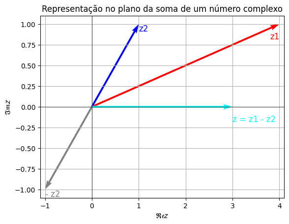

```python
display("Vamos representar no plano complexo a subtração:")
display(Math(r"z_1-z_2=(4+i)-(1+i)"))
plt.quiver( [0,0],[0,0],[(4+1j).real,(1+1j).real], [(4+1j).imag,(1+1j).imag] , angles='xy', scale_units='xy', scale=1, color=['r','b'])
plt.text((4+1j).real-0.2, (4+1j).imag-0.1, 'z1', color='r', fontsize=12, ha='left', va='top')
plt.text((1+1j).real, (1+1j).imag, 'z2', color='b', fontsize=12, ha='left', va='top')
#plt.quiver( [z1.real],[z1.imag],[z2.real], [z2.imag] , angles='xy', scale_units='xy', scale=1, color=['b'])
plt.quiver( [0],[0],[((4+1j)-((1+1j))).real], [((4+1j)-((1+1j))).imag] , angles='xy', scale_units='xy', scale=1, color=['cyan'])
plt.text(((4+1j)-((1+1j))).real, ((4+1j)-((1+1j))).imag-0.1, 'z = z1 - z2', color='cyan', fontsize=12, ha='left', va='top')
plt.quiver( [0],[0],[(-((1+1j))).real], [(-((1+1j))).imag] , angles='xy', scale_units='xy', scale=1, color=['gray'])
plt.text((-((1+1j))).real, (-((1+1j))).imag, '- z2', color='gray', fontsize=12, ha='left', va='top')

plt.xlim(-1.1, 4.1)
plt.ylim(-1.1, 1.1)
plt.xlabel(r'$\mathfrak{Re}z$')
plt.ylabel(r'$\mathfrak{Im}z$')
plt.title('Representação no plano da soma de um número complexo')
plt.grid(True)
plt.axhline(0, color='black', linewidth=0.5)
plt.axvline(0, color='black', linewidth=0.5)
plt.show()
```

# Complexo conjugado

O complexo conjugado de um número complexo $z=a+ib$ é escrito como $z^*$ ou $\bar{z}$ e é dado por: $$z^*=a-ib$$ é fácil ver que

- $zz^*=a^2+b^2=|z|^2$
- $\mathfrak{Re}z=\frac{z+z^*}{2}$
- $\mathfrak{Im}z=\frac{z-z^*}{2i}$
- $(z^*)^*=z$
- $(z_1+z_2)^*=z_1^*+z_2^*$
- $(z_1z_2)^*=z_1^*z_2^*$

Geometricamente a operação de conjugação de $z$ é obtida refletindo o ponto $z$ no eixo real do plano complexo. Observe na figura abaixo o gráfico para dois vetores representando os pontos complexos $z_1=1+i$ e $z_2=1-i$.

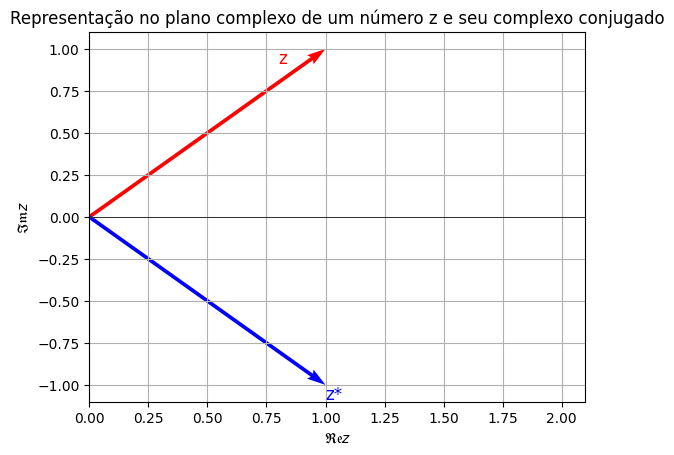

```python
plt.quiver( [0,0],[0,0],[z1.real,z2.real], [z1.imag,z2.imag] , angles='xy', scale_units='xy', scale=1, color=['r','b'])
plt.text((z1).real-0.2, (z1).imag, 'z', color='r', fontsize=12, ha='left', va='top')
plt.text((z2).real, (z2).imag, 'z*', color='b', fontsize=12, ha='left', va='top')
#plt.quiver( [z1.real],[z1.imag],[z2.real], [z2.imag] , angles='xy', scale_units='xy', scale=1, color=['b'])
#plt.quiver( [0],[0],[(z1+z2).real], [(z1+z2).imag] , angles='xy', scale_units='xy', scale=1, color=['orange'])
#plt.text((z1+z2).real, (z1+z2).imag, 'z = z1 + z2', color='orange', fontsize=12, ha='left', va='top')
plt.xlim(0, 2.1)
plt.ylim(-1.1, 1.1)
plt.xlabel(r'$\mathfrak{Re}z$')
plt.ylabel(r'$\mathfrak{Im}z$')
plt.title('Representação no plano complexo de um número z e seu complexo conjugado')
plt.grid(True)
plt.axhline(0, color='black', linewidth=0.5)
plt.axvline(0, color='black', linewidth=0.5)
plt.show()
```

# Divisão

Com a ajuda da operação de conjugação podemos obter a divisão de dois números complexos.

Dado $z_1$ e $z_2$, a divisão de $z_1$ por $z_2$ é $z_3=\frac{z_1}{z_2}$, tal que $z_1=z_3z_2$ $$z_1/z_2=\frac{a_1+ib_1}{a_2+ib_2}$$

$$\frac{z_1}{z_2}=\frac{z_1 z_2^*}{z_2z_2^*}=\frac{z_1 z_2^*}{|z_2|^2}=\frac{z_1 z_2^*}{a_2^2+b_2^2}$$

#### O recíproco é definido como $z^{-1}$ de forma que $zz^{-1}=1$, se $z\ne0$, onde 0 é a identidade aditiva ($0+i0$).

# operando com o produto de $i$.

```python
print("a multiplicação da unidade imaginária se repete, veja:")
print(r"ii=",1j*1j,"a parte real é: ",(1j*1j).real,"a parte imaginária é :",(1j*1j).imag)
print(r"iii=",1j*1j*1j,"a parte real é: ",(1j*1j*1j).real,"a parte imaginária é :",(1j*1j*1j).imag)
print(r"iiii=",1j*1j*1j*1j,"a parte real é: ",(1j*1j*1j*1j).real,"a parte imaginária é :",(1j*1j*1j*1j).imag)
display(Math(r'iiii=i^4=i^0=1,~b~Prove!'))
print(r"iiiii=",1j*1j*1j*1j*1j,"a parte real é: ",(1j*1j*1j*1j*1j).real,"a parte imaginária é :",(1j*1j*1j*1j*1j).imag)
display(Math(r'i^6='))
print(1j**6)
display(Math(r'i^7='))
print(1j**7)
display(Math(r'i^8='))
print(1j**8)
display(Math(r'i^9='))
print(1j**9)
display(Math(r'i^{1000}='))
print(1j**1000)
print(" observe o pequeno erro computacional na parte imaginária que deveria ser nulo") # erro de truncamento
display(Math(r"|{i^{1000}}| = "), abs(1j**1000),Math(r"\mathfrak{Re}(i^{1000}) = "),
        (1j**1000).real,Math(r"\mathfrak{Im}(i^{1000}) = "),(1j**1000).imag)
display(Math("$$"))
```

```
a multiplicação da unidade imaginária se repete, veja:
ii= (-1+0j) a parte real é:  -1.0 a parte imaginária é : 0.0
iii= (-0-1j) a parte real é:  -0.0 a parte imaginária é : -1.0
iiii= (1-0j) a parte real é:  1.0 a parte imaginária é : -0.0
```

$\displaystyle iiii=i^4=i^0=1,~b~Prove!$

```
iiiii= 1j a parte real é:  0.0 a parte imaginária é : 1.0
```

$\displaystyle i^6=$

```
(-1+0j)
```

$\displaystyle i^7=$

```
(-0-1j)
```

$\displaystyle i^8=$

```
(1+0j)
```

$\displaystyle i^9=$

```
1j
```

$\displaystyle i^{1000}=$

```
(1-1.6070832296378168e-13j)
 observe o pequeno erro computacional na parte imaginária que deveria ser nulo
```

$\displaystyle |{i^{1000}}| = $

```
1.0
```

$\displaystyle \mathfrak{Re}(i^{1000}) = $

```
1.0
```

$\displaystyle \mathfrak{Im}(i^{1000}) = $

```
-1.6070832296378168e-13
```

$\displaystyle $

O erro computacional pode ser reduzido sabendo que $i^n$ só pode assumir 4 valores, sendo $n$ um número inteiro positivo

```python
print("podemos reduzir o erro utilizando o fato da exponencial de i ter 4 valores possíveis")
print("logo i elevado a 1000 é ",(1j)**(1000 % 4))
print("onde é o mesmo que elevar i a",(1000 % 4))
```

```
podemos reduzir o erro utilizando o fato da exponencial de i ter 4 valores possíveis
logo i elevado a 1000 é  (1+0j)
onde é o mesmo que elevar i a 0
```